# Taller Grupal II - Análisis Exploratorio de Datos, Universidad ICESI

## Bono

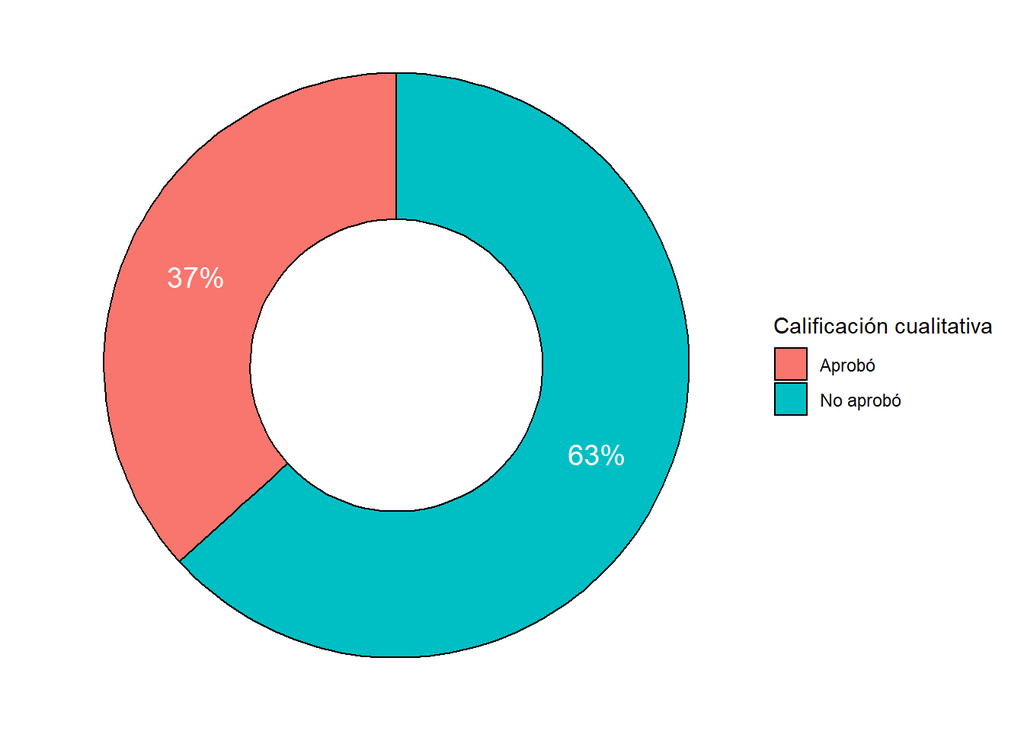

```r
base_f$calificacion = ifelse(base_f$G3 >12, "Aprobó", "No aprobó")
base_f$calificacion = factor(base_f$calificacion)
TABLA_CALIFICACION = tabla_freq(base_f$calificacion, 0)

ggplot(TABLA_CALIFICACION, aes(x=2, y=`Freq. Rel.`, fill=Categoría)) +
  geom_bar(stat="identity", width=1, color="black") +
  coord_polar("y", start=0)+
  labs(fill="Calificación cualitativa")+
  theme_void()+
  geom_text(aes(label = percent(`Freq. Rel.`)),position = position_stack(vjust = 0.5),color = "white", size=5)+
  xlim(0.5, 2.5)
```

La mayoría de los estudiantes no aprobaron el curso.

### Calificación vs Medu

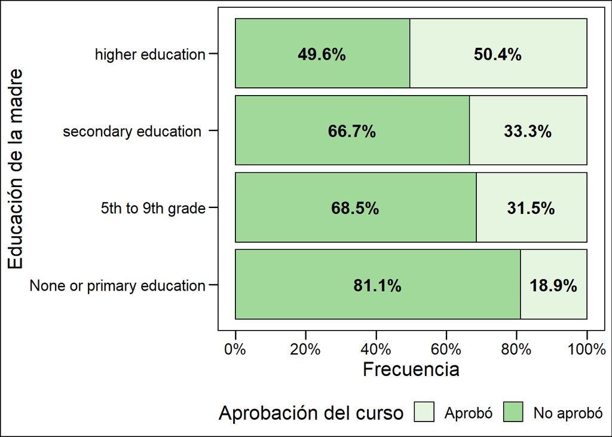

```r
TABLA_GRADE=as.data.frame(prop.table(table(base_f$Medu,base_f$calificacion),1))

ggplot(TABLA_GRADE, aes(x=Var1, y=Freq, fill=Var2))+
geom_bar(stat = "identity", color="black")+
 labs(x="Educación de la madre",y="Frecuencia", fill="Aprobación del curso")+
scale_fill_brewer(palette = "Greens")+
scale_y_continuous(limits = c(0,1), breaks = seq(0,1,0.2), labels = percent)+
geom_text(aes(x=Var1, y=Freq, label=percent(Freq, accuracy = 0.1)), position= position_stack(vjust = 0.5), fontface = "bold", size=5)+
coord_flip()+
theme_base()+
theme(legend.position="bottom")
```

Esta información sugiere que es más frecuente encontrar estudiantes que aprobaron el curso cuando la educación de la madre es mayor.

### Calificación vs Absences

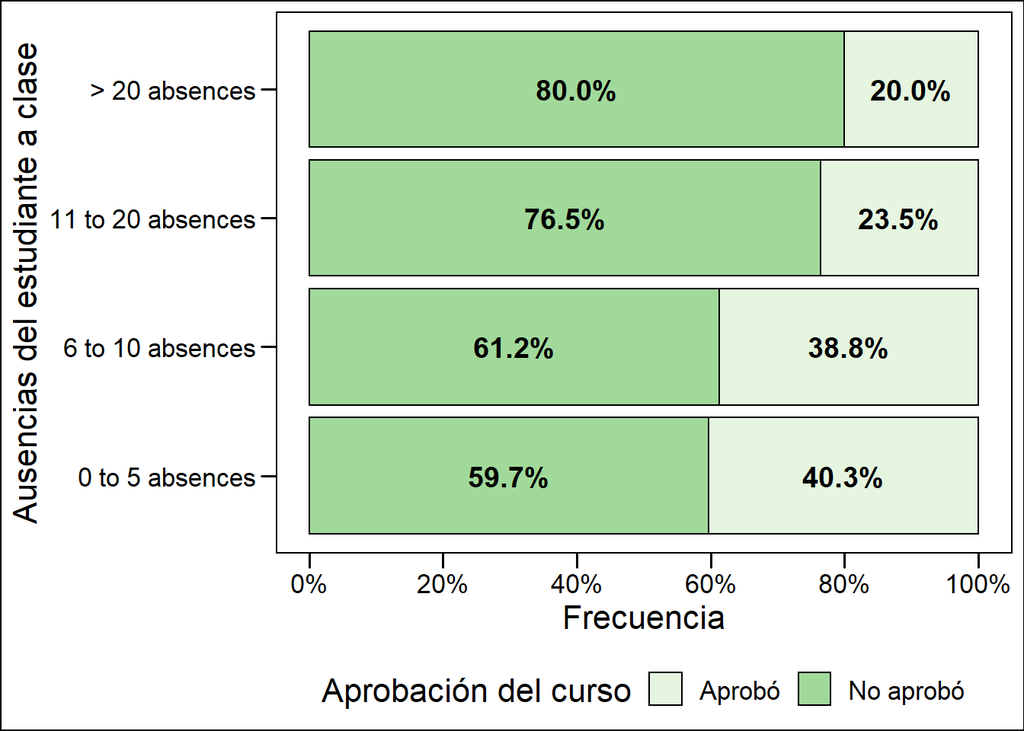

```r
TABLA_GRADE=as.data.frame(prop.table(table(base_f$absences,base_f$calificacion),1))

ggplot(TABLA_GRADE, aes(x=Var1, y=Freq, fill=Var2))+
geom_bar(stat = "identity", color="black")+
 labs(x="Ausencias del estudiante a clase",y="Frecuencia", fill="Aprobación del curso")+
scale_fill_brewer(palette = "Greens")+
scale_y_continuous(limits = c(0,1), breaks = seq(0,1,0.2), labels = percent)+
geom_text(aes(x=Var1, y=Freq, label=percent(Freq, accuracy = 0.1)), position= position_stack(vjust = 0.5), fontface = "bold", size=5)+
coord_flip()+
theme_base()+
theme(legend.position="bottom")
```

Esta información sugiere que es más frecuente encontrar estudiantes que aprobaron el curso cuando tuvieron menos ausencias.

### Clasificación vs Paid

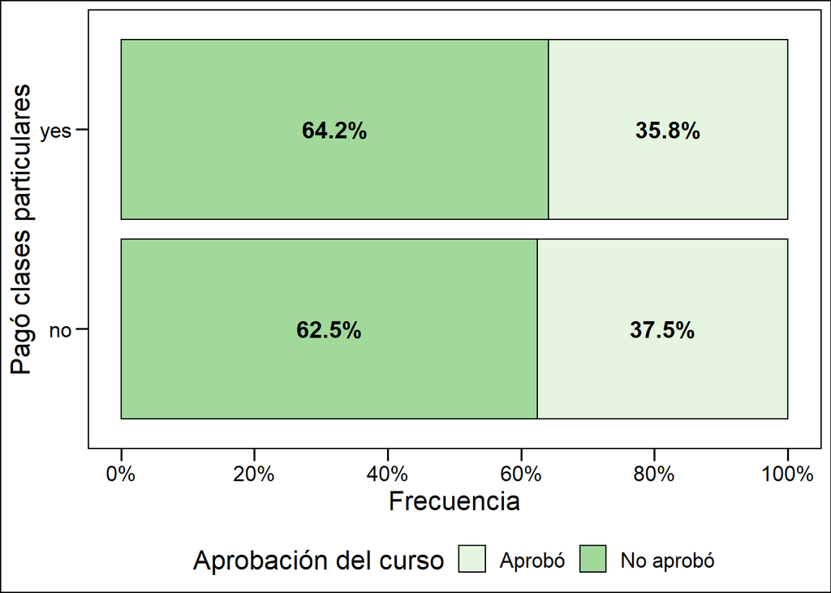

```r
TABLA_GRADE=as.data.frame(prop.table(table(base_f$paid,base_f$calificacion),1))

ggplot(TABLA_GRADE, aes(x=Var1, y=Freq, fill=Var2))+
geom_bar(stat = "identity", color="black")+
 labs(x="Pagó clases particulares",y="Frecuencia", fill="Aprobación del curso")+
scale_fill_brewer(palette = "Greens")+
scale_y_continuous(limits = c(0,1), breaks = seq(0,1,0.2), labels = percent)+
geom_text(aes(x=Var1, y=Freq, label=percent(Freq, accuracy = 0.1)), position= position_stack(vjust = 0.5), fontface = "bold", size=5)+
coord_flip()+
theme_base()+
theme(legend.position="bottom")
```

Esta información sugiere que así se hayan pagado clases particulares o no, los estudiantes aprueban el curso con una proporción muy similar.